# Expanded mpg Linear Regression Model - interactive Analysis in Shiny

*EXECUTIVE SUMMARY*

We presented an mpg Linear Model project in support of the Coursera ‘Linear Regression’ class and in this project we will expand by enabling interactive data exploration and creating a model based on the conclusions of our previous study.

We will again rely on the ‘mtcars’ dataset to demonstrate a Linear Regression model over data collected by the Motor Trend magazine, we are interested in exploring the relationship between a set of variables and miles per gallon (MPG) (outcome) and the interactions on number of cylinder on an specific model.

*DELIVERABLES*

Create a Shiny application and deploy it on Rstudio’s servers. Second, you will use Slidify or Rstudio Presenter to prepare a reproducible pitch presentation about your application.

*LINEAR MODEL*

Consider the following conclusions from our baseline project :

I. “Is an automatic or manual transmission better for MPG” -> We think that whilst the exploratory analysis shows different distributions for Auto/Manual relative to mpg/weight and manual proved to be only slightly better than automatic transmission.

2. We think we can leave ‘am’ out of the model and opt for a simpler version.

*Proposed Model*

We are proposing the following simplyfied model considering only weight, horsepowe and number of cylinders :

mpg.p <- 35.84 - 3.18140*i.wt - 0.02312*i.hp - 3.35902*i.cyl6 - 3.18588*i.cyl8

**Coefficients Interpretation**

Revised Model : mtcars.lm <- lm(mpg ~ wt+hp+cyl, data = mtcars)

```
##
## Call:
## lm(formula = mpg ~ wt + hp + cyl, data = mtcars)
##
## Residuals:
##     Min      1Q  Median      3Q     Max
## -4.2612 -1.0320 -0.3210  0.9281  5.3947
##
## Coefficients:
##             Estimate Std. Error t value Pr(>|t|)
## (Intercept) 35.84600    2.04102  17.563 2.67e-16 ***
## wt          -3.18140    0.71960  -4.421 0.000144 ***
## hp          -0.02312    0.01195  -1.934 0.063613 .
## cyl6        -3.35902    1.40167  -2.396 0.023747 *
## cyl8        -3.18588    2.17048  -1.468 0.153705
## ---
## Signif. codes:  0 '***' 0.001 '**' 0.01 '*' 0.05 '.' 0.1 ' ' 1
##
## Residual standard error: 2.44 on 27 degrees of freedom
## Multiple R-squared:  0.8572, Adjusted R-squared:  0.8361
## F-statistic: 40.53 on 4 and 27 DF,  p-value: 4.869e-11
```

All factors held constant we have a baseline mpg performance of 35.8 (intercept) and every ton would bring down by 3.18mpg, while changes on horsepower would have and effect of only 0.02 mpg. Model base considers a 4cyl car so then a 6 cal factore in would bring down mpg by 3.35 mpg and 8 cyl would reduce by 3.18.

*MODEL DIAGNOSTICS / INFERENCE*

**->** The residuals of the model are nearly normal. Normal Q-Q below exhibits some minor irregularities (Corolla, F128, Imperial) as potential outliers and that might be cause for concern, however, Upper left hand points have low leverage, low influence (per 02_04 lecture slide 5/16).

**->** The variability of the residuals is nearly constant. The variability of the data around the line increases with larger values of x so we have some concerns as shown in Res vs Fitted and Scale-Location. However utilizing Breusch-Pagan (aka Cook-Weisberg) test for heteroskedasticity it results in a p value around 0.05 so we will proceed assuming constant variability.

Breusch-Pagan test for heteroskedasticity

```r
ncvTest(mtcars.lm2)
```

```
## Non-constant Variance Score Test
## Variance formula: ~ fitted.values
## Chisquare = 3.374465    Df = 1     p = 0.06621408
```

Model Diagnostics Plots

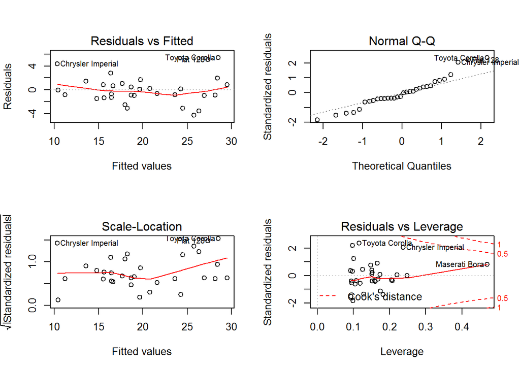

*EXPLORATORY ANALYSIS*

mtcars dataset accounts for 32 observations and 11 variables as numeric. We have converted cyl as factor.

*CONCLUSIONS*

I. We found value on the interaction offered by the exploratory solution in Shiny.

We reflect on the value of a data product as the augmented insight that can be gained beyond of static visualization and also appreciatte the feedback of the solution. Whilst we are not expert creating Shiny solutions as of yet, we found it very practical and also value the possibility to better communicate project intent and outcomes.